## Explanatory Data Analysis

#### Loading Data set and inspecting summary statistics as well as missing data:

```r
library(tidyverse)
library(naniar)

dataset <- read.csv("C:/Users/Joey/Desktop/applied-stats/datasets/data1.csv")

#glimpse(dataset) # looking at the var types of each

summary(dataset) # visually looking at the sum. stats of the vars in the data.
```

```
##      Make              Model                Year      Engine.Fuel.Type
##  Length:11914       Length:11914       Min.   :1990   Length:11914
##  Class :character   Class :character   1st Qu.:2007   Class :character
##  Mode  :character   Mode  :character   Median :2015   Mode  :character
##                                        Mean   :2010
##                                        3rd Qu.:2016
##                                        Max.   :2017
##
##    Engine.HP      Engine.Cylinders Transmission.Type  Driven_Wheels
##  Min.   :  55.0   Min.   : 0.000   Length:11914       Length:11914
##  1st Qu.: 170.0   1st Qu.: 4.000   Class :character   Class :character
##  Median : 227.0   Median : 6.000   Mode  :character   Mode  :character
##  Mean   : 249.4   Mean   : 5.629
##  3rd Qu.: 300.0   3rd Qu.: 6.000
##  Max.   :1001.0   Max.   :16.000
##  NA's   :69       NA's   :30
##  Number.of.Doors Market.Category    Vehicle.Size       Vehicle.Style
##  Min.   :2.000   Length:11914       Length:11914       Length:11914
##  1st Qu.:2.000   Class :character   Class :character   Class :character
##  Median :4.000   Mode  :character   Mode  :character   Mode  :character
##  Mean   :3.436
##  3rd Qu.:4.000
##  Max.   :4.000
##  NA's   :6
##   highway.MPG        city.mpg        Popularity        MSRP
##  Min.   : 12.00   Min.   :  7.00   Min.   :   2   Min.   :   2000
##  1st Qu.: 22.00   1st Qu.: 16.00   1st Qu.: 549   1st Qu.:  21000
##  Median : 26.00   Median : 18.00   Median :1385   Median :  29995
##  Mean   : 26.64   Mean   : 19.73   Mean   :1555   Mean   :  40595
##  3rd Qu.: 30.00   3rd Qu.: 22.00   3rd Qu.:2009   3rd Qu.:  42231
##  Max.   :354.00   Max.   :137.00   Max.   :5657   Max.   :2065902
##
```

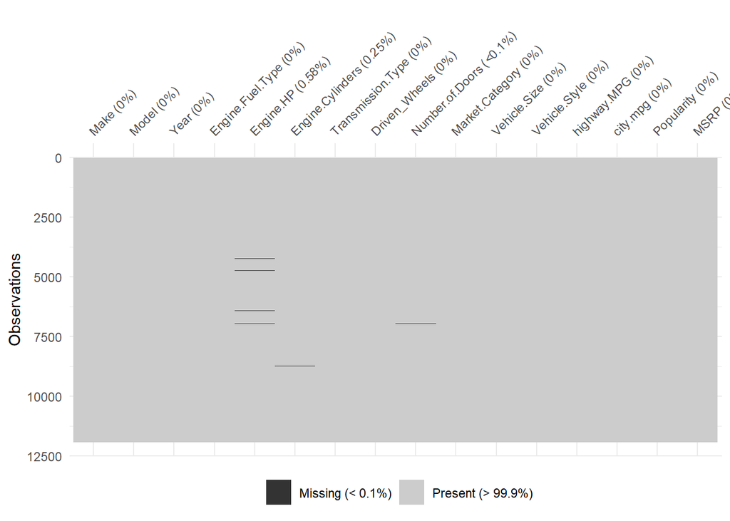

```r
vis_miss(dataset) # viz looking @ missing values
```

We can see there is a number of variables that contain NA’s

#### Var. that contain NA:

- Engine.HP = 69
- Engine.Cylinders = 30
- Number.of.Doors = 6

Since many of the missing values seem to be found using any number of automobile spec. websites we will input them into the data set below instead of removing those observations so that we can fully utilize the features and data provided.

#### Number of Doors:

All NA values here belong to Tesla Model S and Ferrari FF. We were able to find and input these values.

```r
#updating NA for Doors
dataset[6931:6935,9] <- 4 # Tesla model S
dataset[4667,9] <- 2 # Ferrari FF
```

#### Engine Cylinders

The Mazda RX-7, and RX-8 use a unique rotary Engine and thus technically have no cylinders.

On the EV side of the data set we find the remaining NA values and they have been updated to 0 since electric vehicles do not have engine cylinders. future consideration for a substitute value would be ideal here as the automobile market gains more and more Electric vehicles. This substitute value would help to leverage a way to add accurate predictions and values using this metric when comparing many EV.

```r
dataset[1984:1985, 6] <- 0 # chevy bolt EV
dataset[3717:3720, 6] <- 0 # volkswagen e-golf
dataset[5779:5781,6] <- 0 # mitsubishi i-miev
dataset[8374,6] <- 0 # toyota rav4-ev
dataset[8696:8715, 6] <- 0 # mazda rotary engine RX7 AND RX8
```

#### Engine HP

Certain cars specifically electric vehicles do not report “horsepower” but instead will report Kilowatts (KW) so we expect to see many Missing values when dealing with Electric vehicles.

Exceptions to this: Chevy Spark - GM reports 140 HP i3 - BMW reports 170-181 HP i-MiEV - Mitsubishi reports 66 HP e-golf - Volkswagen reports 115 HP

we could possibly create a ML algo to predict what the HP is… but since they are reported on a different scale, and are of a different type of vehicle maybe it would be better off changing the “missing values” into 0s.

```r
dataset[8374,5] <- 154 # toyota RAV4-EV
dataset[2906:2909,5] <- 305 # lincoln Continental
dataset[4204:4207,5]<- 168 # ford escape
dataset[4915:4920,5]<- 193 # ford freestar
dataset[c(5826,5831,5832,5834,5840,5841),5]<- 305 # chevy impala flex-fuel
dataset[c(6909,6911,6917,6919),5]<-240 # lincoln mkz
dataset[6579, 5] <- 200 # mercedes-benz m-class
dataset[8375:8376,5]<-154 # 2013 rav4 EV and 2014
dataset[540:542, 5] <- 111 # fiat 500 e - from edmunds
dataset[9851:9855,5]<- 109 # kia soul Ev
dataset[4706:4707,5] <- 123 # honda fit Ev
dataset[c(4786,4790,4799),5] <- 143 # ford focus ev
dataset[5779,5] <- 66 # mitsubishi i-miev
dataset[6386:6395,5] <- 107 # nissan leaf
dataset[6923,5] <- 302 # base tsla model s 2014
dataset[6922,5] <- 302 # 2nd tsla model s 2014
dataset[6925,5] <- 362 # 3rd tsla model s 2014
dataset[6924,5] <- 416 # 4th tsla model s 2014
dataset[6926:6927,5]<- 329 # tsla model s 2015
dataset[6930, 5]<- 362 # tsla model s 2015
dataset[6928,5]<- 416 # tsla model s 2015
dataset[6929,5]<- 691 # tsla model s 2015
dataset[6932,5]<-259 # tsla model s 2016
dataset[6935,5]<-315
dataset[6934:6936,5] <- 373 # tsla model s 2016
dataset[6936,5]<-373# tsla model s 2016
dataset[c(6931,6937),5]<-417# tsla model s 2016
dataset[6939,5]<- 503# tsla model s 2016
dataset[c(6933,6938),5] <- 691# tsla model s 2016

dataset[11322:11324,4] <- 'regular unleaded' # suzuki verona missing fuel type


car_data <- dataset
```

#### “Unknown” Data values in the Transmission.Type category

Values of “Unknown” were discovered in the data. These Unknown values are publicly and easily accessible information and we were able to update the database with the proper assignments.

```r
car_data[1290:1291, 7] <- "AUTOMATIC" # oldsmobile achieva
car_data[4692,7]<- "MANUAL" # cheaper firebird
car_data[4693:4694,7]<- "AUTOMATIC" #more expensive firebird
car_data[6159,7] <- "MANUAL" # GMC Jimmy cheaper 99
car_data[6161,7] <- "AUTOMATIC" # GMC jimmy 99
car_data[6166,7] <- "MANUAL" #gmc jimmy 00
car_data[6175,7]<- "AUTOMATIC" # gmc jimmy 00
car_data[6367,7] <- "MANUAL" # chrysler le baron
car_data[6369,7] <- "AUTOMATIC"# chrysler le baron
car_data[c(8043,8044,8047,8048,8049,8050,8052,8054),7] <- "AUTOMATIC" # dodge ram 150
```

There are many chr and int types so we will change them into a factor where needed so that we can adequately plot the data.

```r
car_data$Make <- as.factor(car_data$Make)
car_data$Engine.Fuel.Type<- as.factor(car_data$Engine.Fuel.Type) # chr
car_data$Engine.HP<- as.numeric(car_data$Engine.HP) # dbl
car_data$Engine.Cylinders<-as.factor(car_data$Engine.Cylinders) # dbl
car_data$Transmission.Type<-as.factor(car_data$Transmission.Type) # chr
car_data$Driven_Wheels<- as.factor(car_data$Driven_Wheels) # chr
car_data$Number.of.Doors<- as.integer(car_data$Number.of.Doors) # dbl
car_data$Vehicle.Size<-as.factor(car_data$Vehicle.Size) # chr
car_data$Vehicle.Style<-as.factor(car_data$Vehicle.Style) # chr
car_data$Market.Category<-as.factor(car_data$Market.Category) # chr
```

#### “Not Applicable” Values:

upon investigation of the Market Category section we found many “N/A” values (3,742). These values seem to be implicitly add N/A values, which could in fact mean there is no applicable group that it fits into. we will change this N/A to “No Category” to avoid any confusion with Missing value data.

```r
# change so that we can handle the "N/A" which is NOT an NA
car_data$Market.Category<-as.character(car_data$Market.Category)
sum(car_data$Market.Category == "N/A") #3742 this is our benchmark
```

```
## [1] 3742
```

```r
# reading as not applicable we will change to no category
car_data$Market.Category[car_data$Market.Category == "N/A"] <- "No Category"

# sanity check should be 0
sum(car_data$Market.Category == "N/A")
```

```
## [1] 0
```

```r
# change to match rest of data type (factor)
car_data$Market.Category<-as.factor(car_data$Market.Category)
```

Typo Audi MPG

```r
car_data[1120,13] <- 34
```

#### Visuals on cleaned dataset

Potential Transformations needed: - Engine HP slight right skew … log helps this - popularity both right and left skewed (when transformed or not) seems to be a metric we can leave out? - city.mpg this is skewed to the right.. mostly because of electric vehicles no transform fixes this issue. - highway.mpg same as city… we see a strong right skew. electric vehicles skew the data heavily

Viz - 1

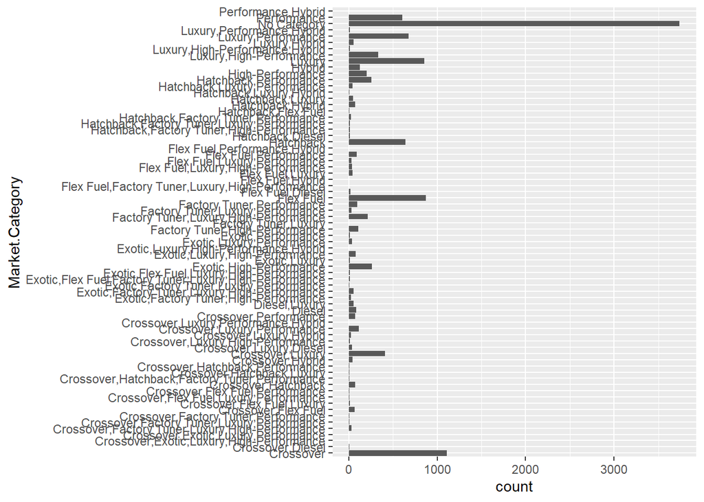

```r
view(car_data)
car_data%>%ggplot(aes(Market.Category))+
  geom_bar()+coord_flip()
```

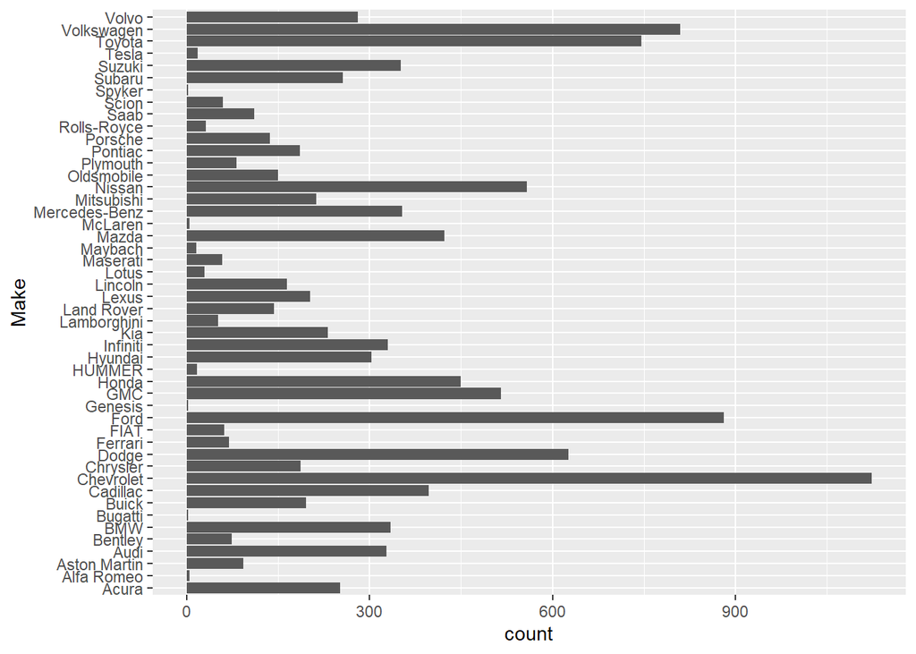

```r
# which make of car has the highest count?
car_data %>% ggplot(aes(Make)) +
  geom_bar(stat = 'count') + coord_flip()
```

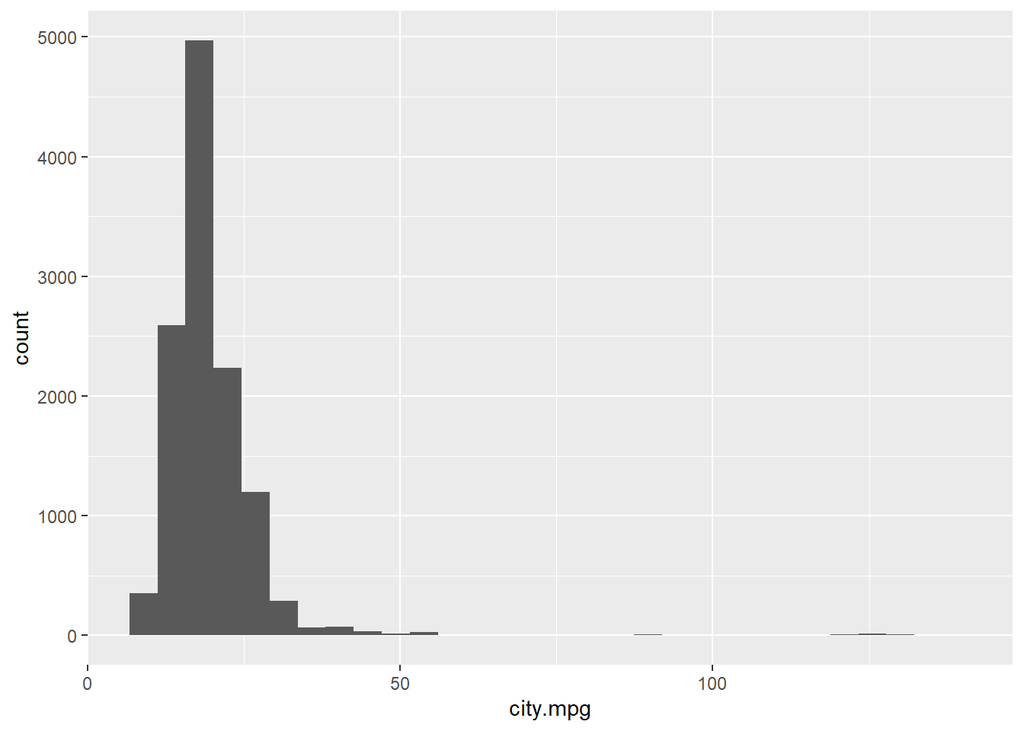

```r
# city mpg distribution between cars
 car_data %>% ggplot(aes(city.mpg))+
   geom_histogram()
```

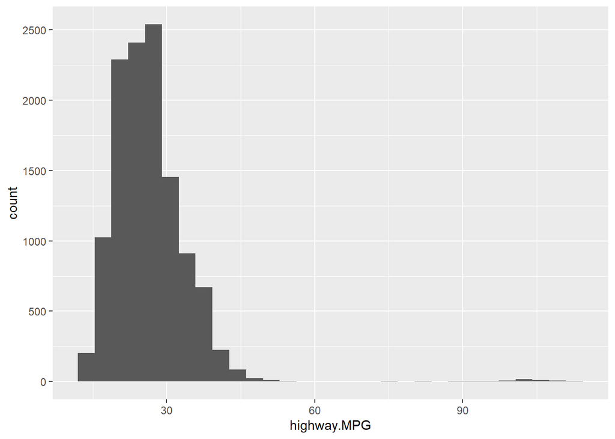

```r
# hwy dist. between cars
car_data %>% ggplot(aes(highway.MPG))+
  geom_histogram() # is there a report for EV?
```

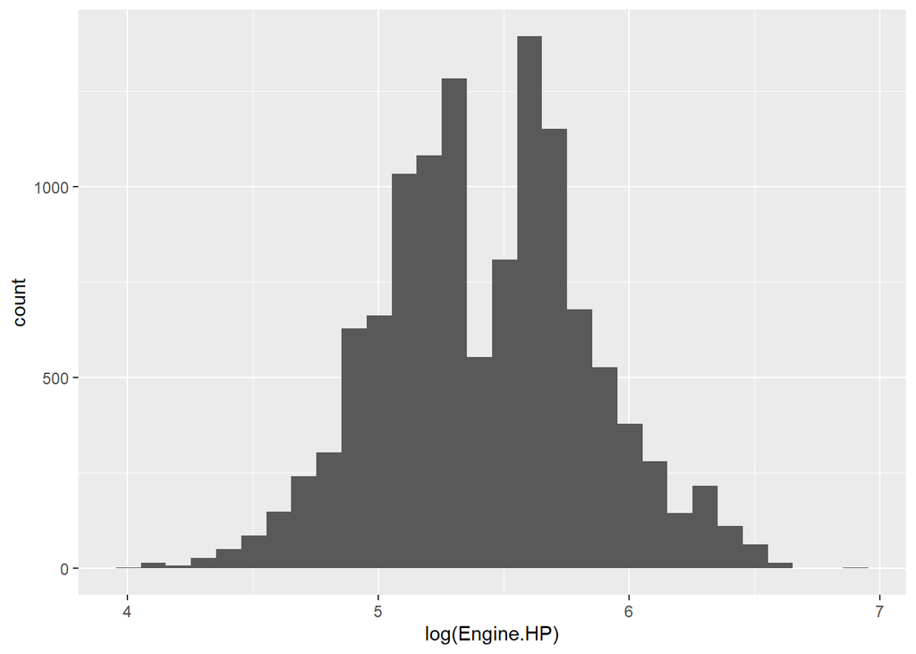

```r
# Engine HP dist.
car_data %>% ggplot(aes(log(Engine.HP)))+ # log provides best view
  geom_histogram()
```

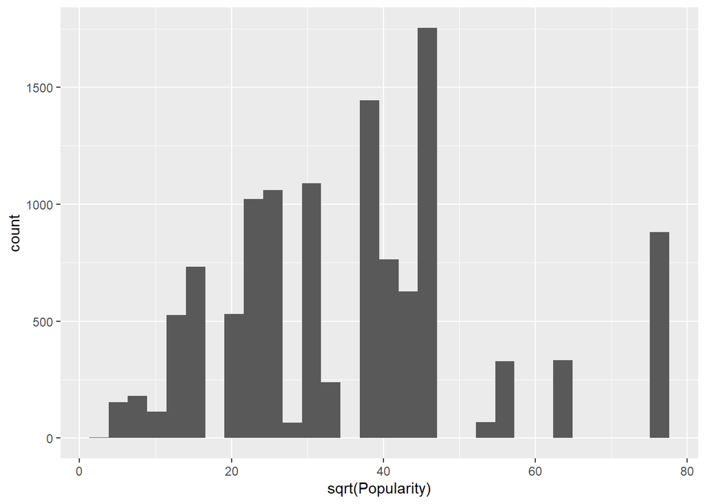

```r
car_data %>% ggplot(aes(sqrt(Popularity)))+
  geom_histogram() # not sure how this is rated.. but theres a huge part missing
```

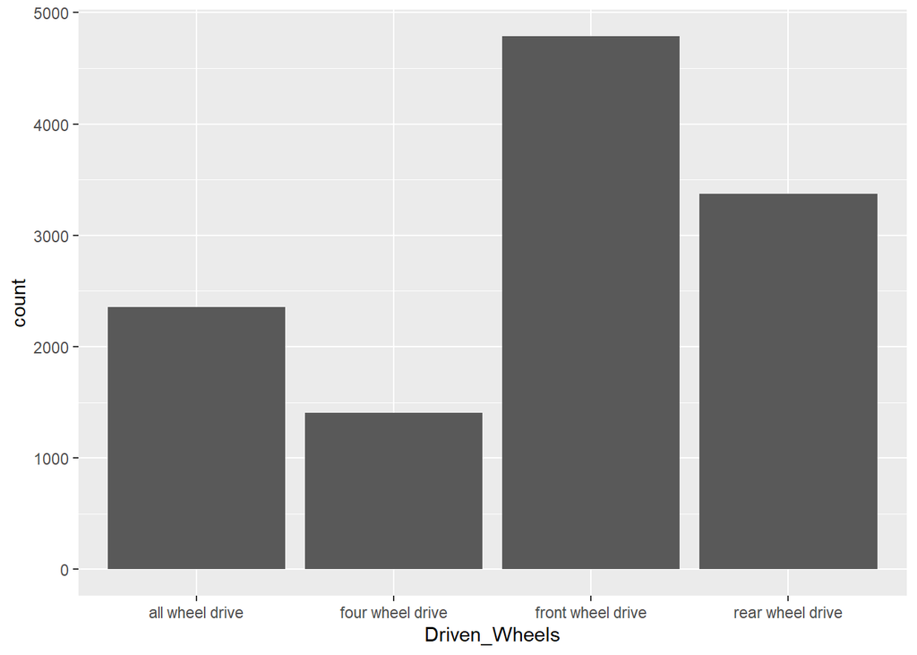

```r
 # most tend to be found in 0 - just above 2000

# representation of drive type (AWD,FWD, 4WD etc)
car_data %>% ggplot(aes(Driven_Wheels))+
  geom_bar()
```

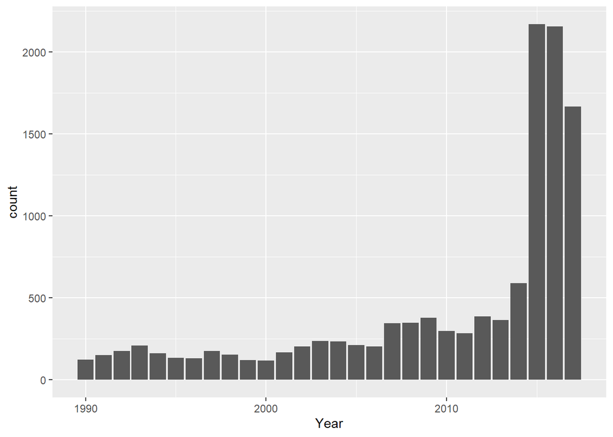

```r
# left skewed data for Year (which makes sense since we expect to be selling "newer" vehicles)
car_data %>% ggplot(aes(Year)) +
  geom_bar()
```

Viz 2 - MSRP broken into different ranges.

Logged version seems to have a bimodal distribution which makes sense since we essentiall have a used and new market price for cars. older vehicles (specifically those in the 90s) seem to have a fixed price of 2k.

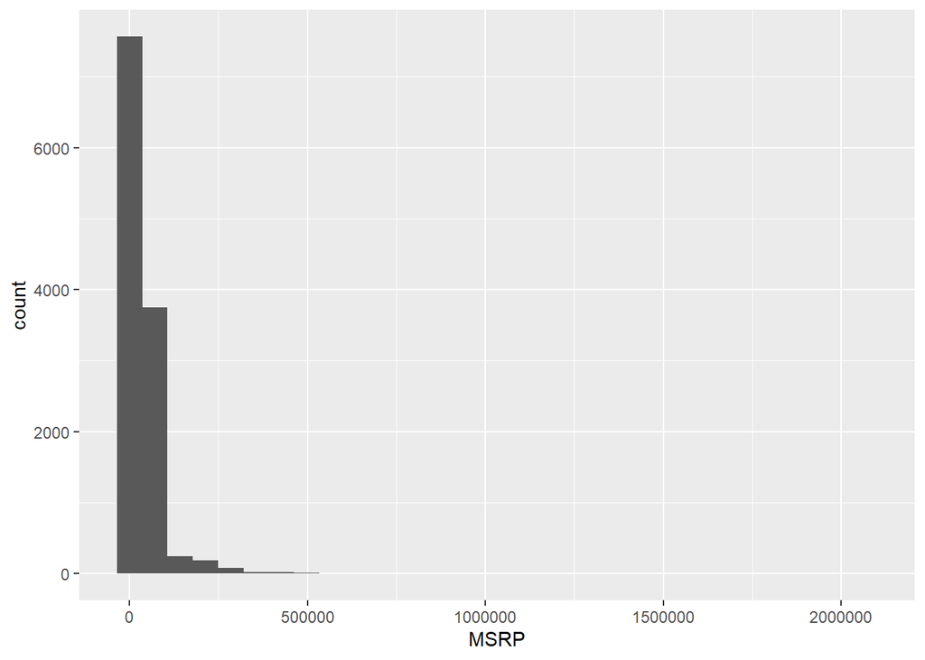

```r
car_data %>% ggplot(aes(MSRP))+
  geom_histogram()
```

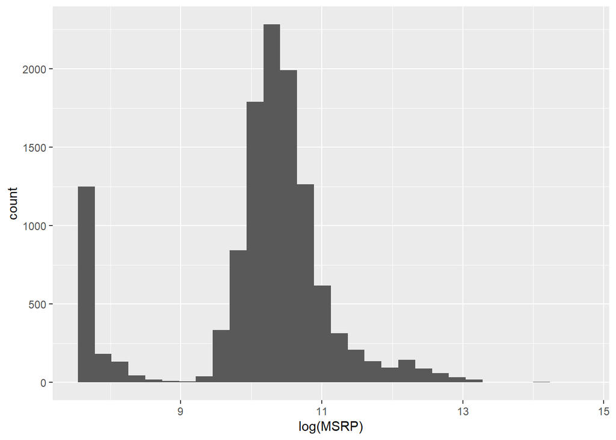

```r
car_data%>% ggplot(aes(log(MSRP)))+
  geom_histogram()
```

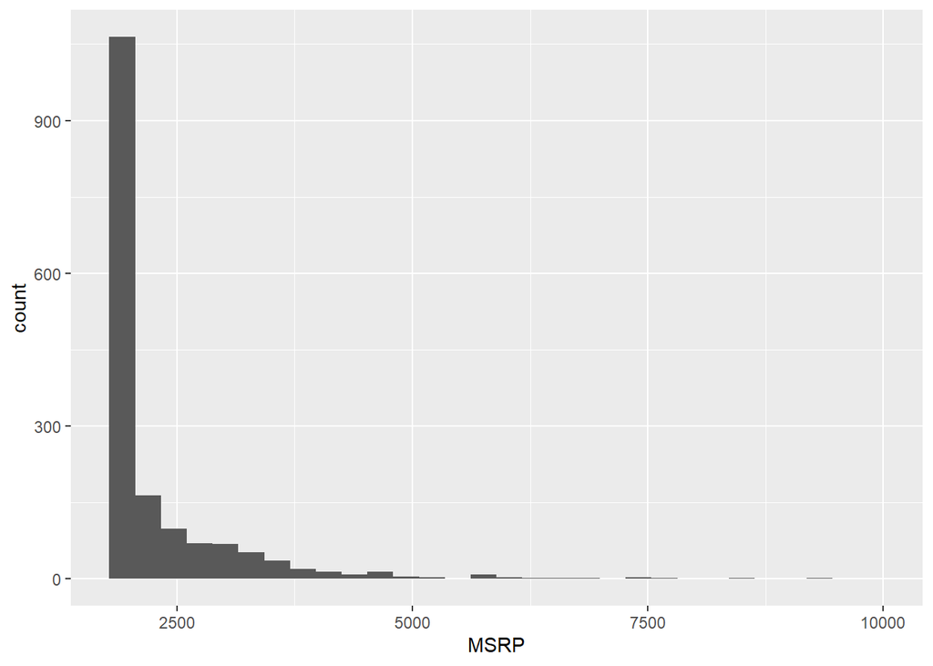

```r
car_data %>% filter(MSRP <=10000) %>% ggplot(aes(MSRP)) +
  geom_histogram()
```

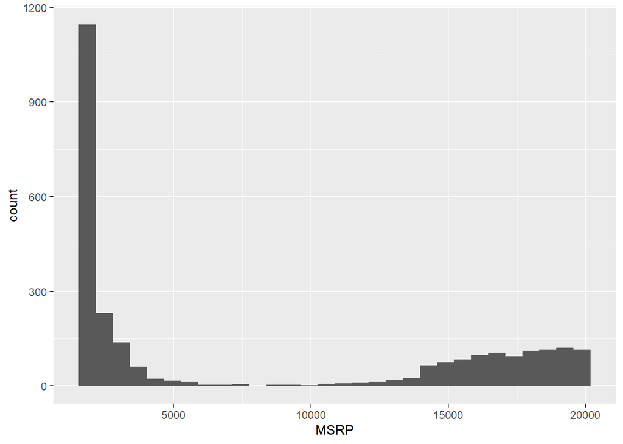

```r
car_data %>% filter(MSRP <=20000) %>% ggplot(aes(MSRP)) +
  geom_histogram()
```

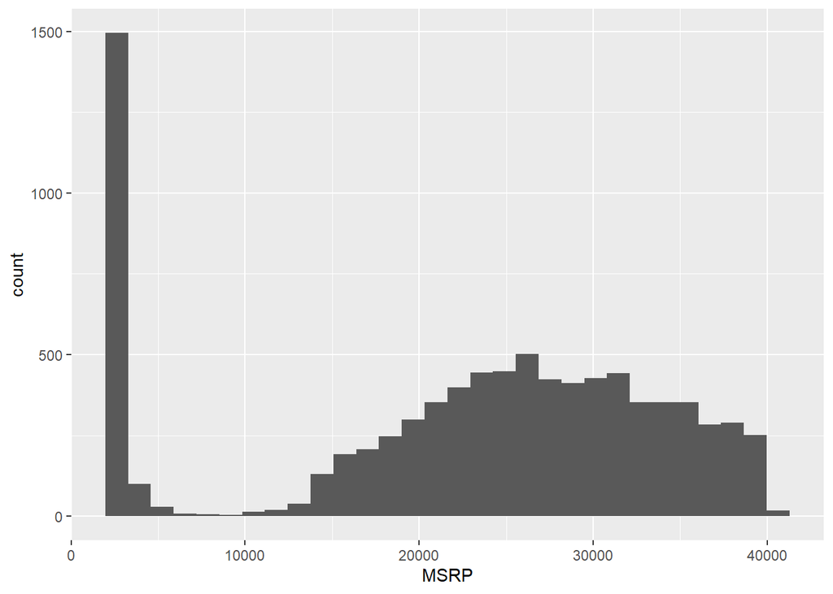

```r
car_data %>% filter(MSRP <=40000) %>% ggplot(aes(MSRP)) +
  geom_histogram()
```

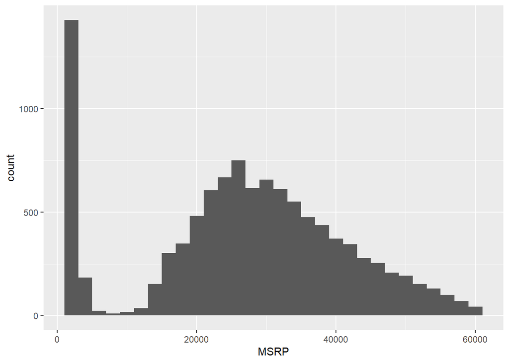

```r
car_data %>% filter(MSRP <=60000) %>% ggplot(aes(MSRP)) +
  geom_histogram()
```

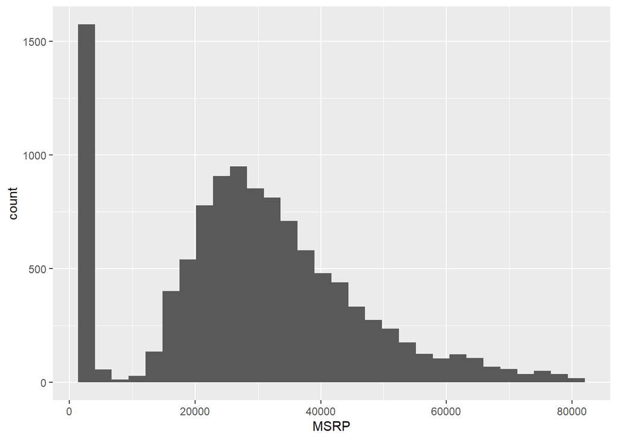

```r
car_data %>% filter(MSRP <=80000) %>% ggplot(aes(MSRP)) +
  geom_histogram()
```

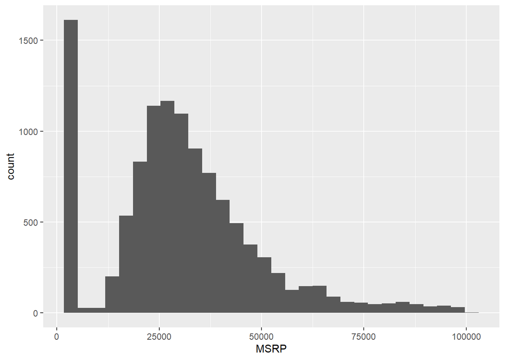

```r
car_data %>% filter(MSRP <=100000) %>% ggplot(aes(MSRP)) +
  geom_histogram()
```

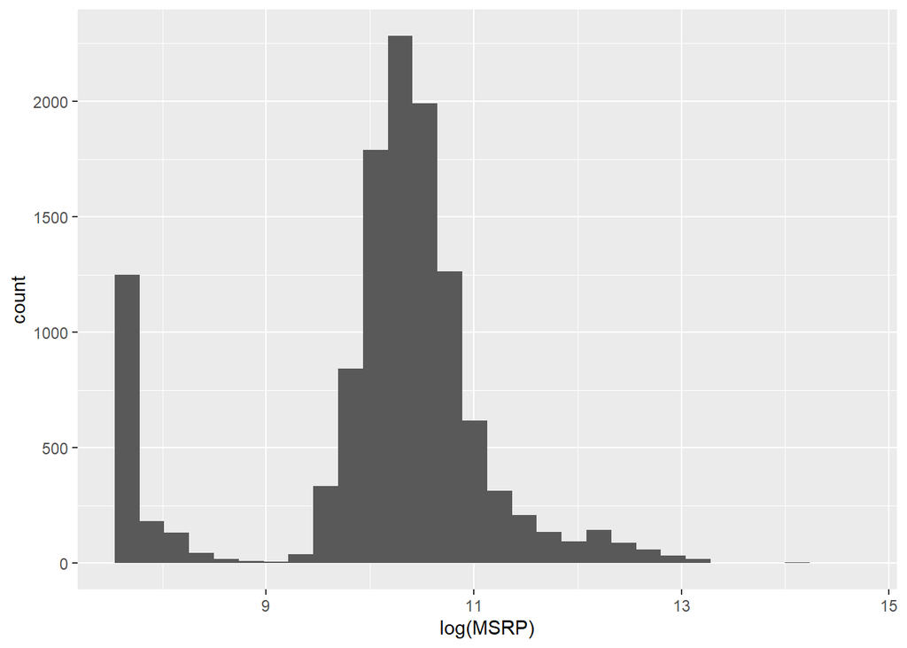

```r
car_data %>% ggplot(aes(log(MSRP)))+
  geom_histogram()
```

Viz 3

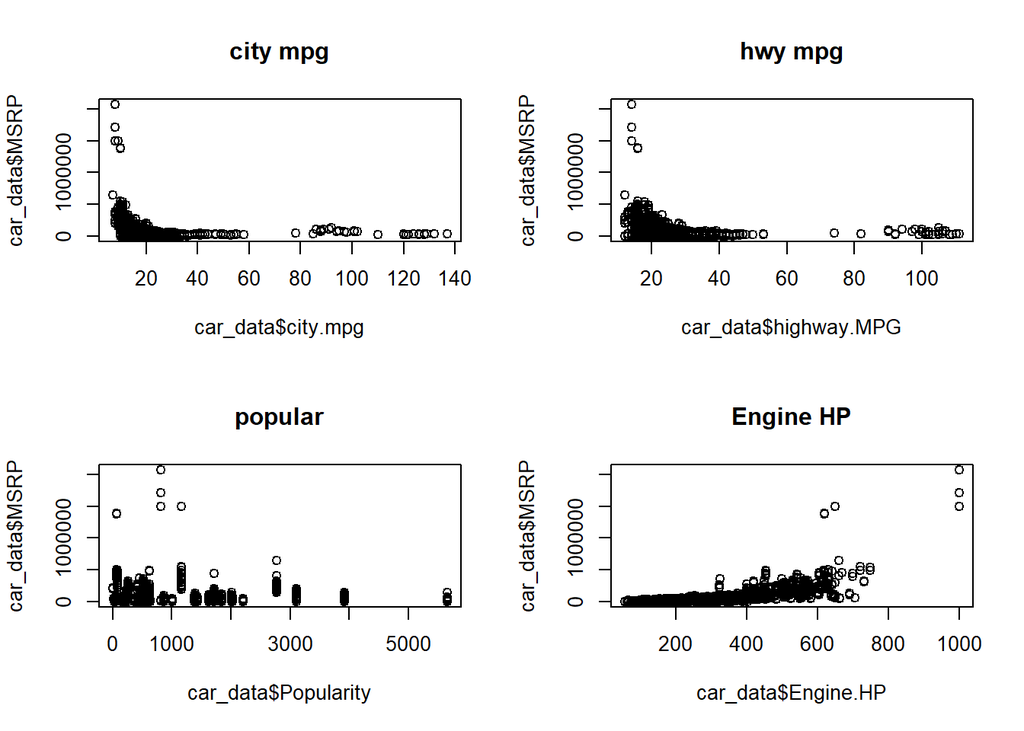

```r
# numerical
par(mfrow = c(2,2))
# city mpg
plot(car_data$city.mpg,car_data$MSRP, main = "city mpg")
#hwy mpg
plot(car_data$highway.MPG, car_data$MSRP, main = "hwy mpg")
# popularity
plot(car_data$Popularity, car_data$MSRP, main = "popular") # this looks irrelevant ?

plot(car_data$Engine.HP, car_data$MSRP, main="Engine HP")
```

viz 3 with log MSRP

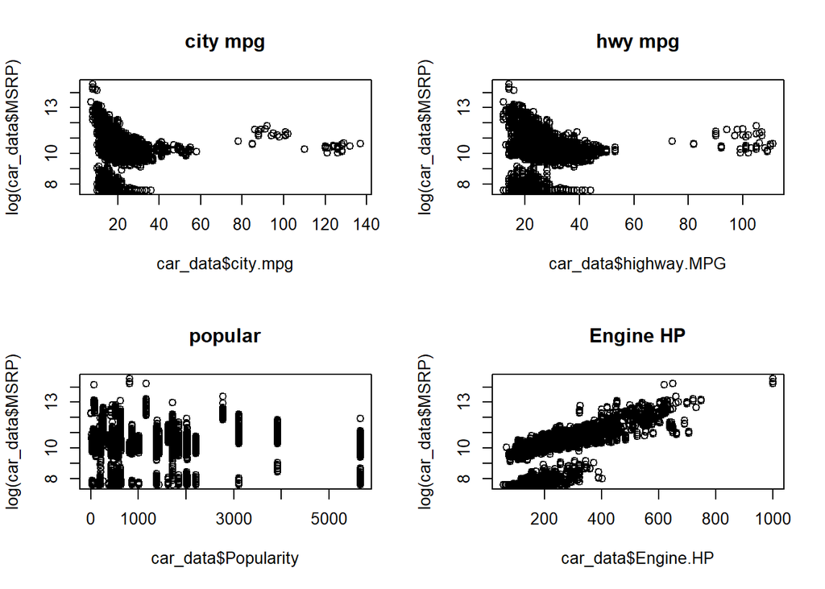

```r
# numerical
par(mfrow = c(2,2))
# city mpg
plot(car_data$city.mpg, log(car_data$MSRP), main = "city mpg")
#hwy mpg
plot(car_data$highway.MPG, log(car_data$MSRP), main = "hwy mpg")
# popularity
plot(car_data$Popularity, log(car_data$MSRP), main = "popular") # this looks irrelevant ?

plot(car_data$Engine.HP, log(car_data$MSRP), main="Engine HP")
```

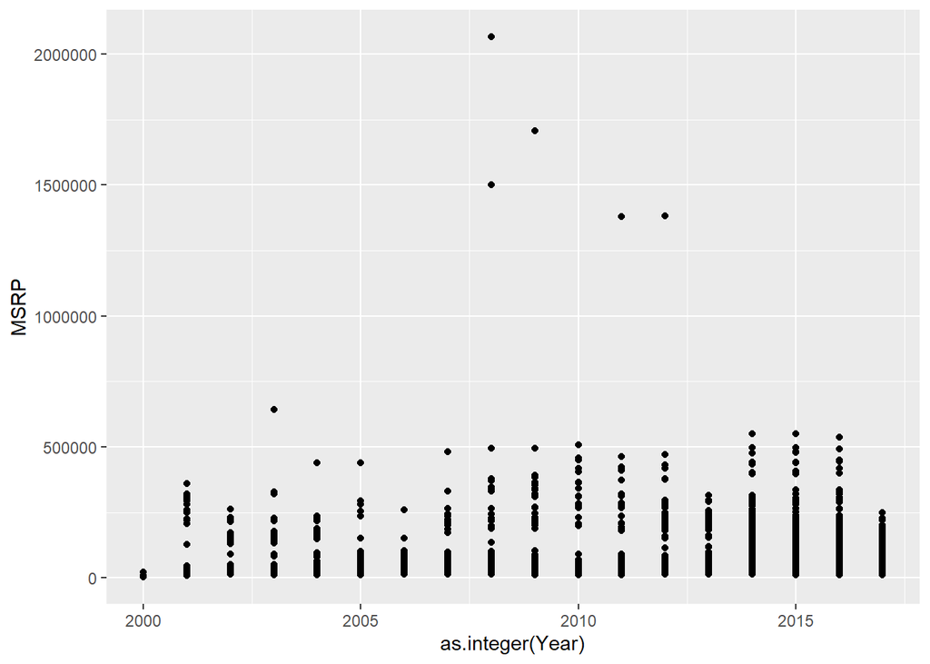

```r
car_data %>% filter(Year >= 2000) %>% ggplot(aes(as.integer(Year), MSRP))+
  geom_point()
```

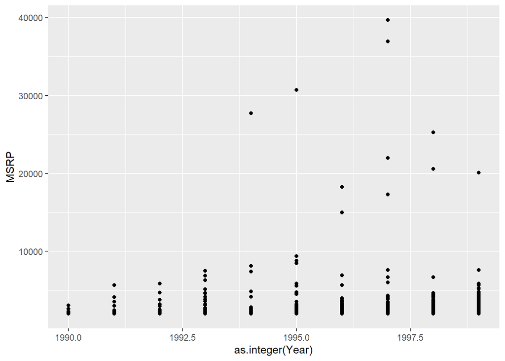

```r
car_data %>% filter(Year < 2000) %>% ggplot(aes(as.integer(Year), MSRP))+
  geom_point()
```

Viz 5

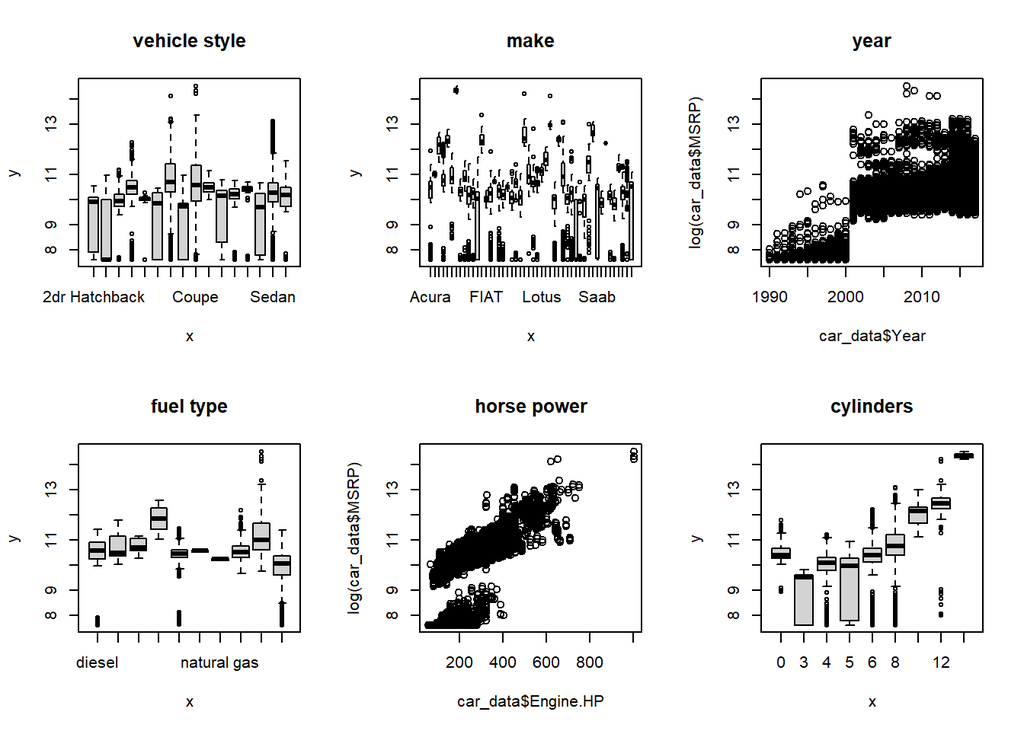

```r
library(ggplot2)

# categorical
par(mfrow = c(2,3))
# Veh. Style
plot(car_data$Vehicle.Style, log(car_data$MSRP), main = "vehicle style")
# make
plot(car_data$Make,log(car_data$MSRP), main = "make")
# year
plot(car_data$Year, log(car_data$MSRP), main = "year")

# fuel type
plot(car_data$Engine.Fuel.Type, log(car_data$MSRP), main = "fuel type")
# HP
plot(car_data$Engine.HP, log(car_data$MSRP), main = "horse power")
# cylinders
plot(car_data$Engine.Cylinders, log(car_data$MSRP), main = "cylinders")
```

Viz 6

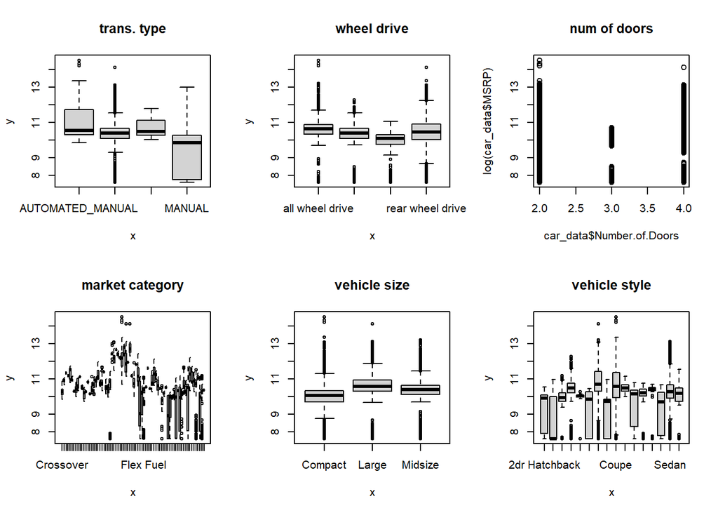

```r
par(mfrow = c(2,3))
# transmission type
plot(car_data$Transmission.Type, log(car_data$MSRP), main = "trans. type")
# wheel drive
plot(car_data$Driven_Wheels, log(car_data$MSRP), main = "wheel drive")
# number of doors
plot(car_data$Number.of.Doors, log(car_data$MSRP), main = "num of doors")
# market category
plot(car_data$Market.Category, log(car_data$MSRP), main = "market category")  #there is big chunk of missing values this may be unreliable
# size
plot(car_data$Vehicle.Size, log(car_data$MSRP), main = "vehicle size")
# style
plot(car_data$Vehicle.Style, log(car_data$MSRP), main = "vehicle style")
```

Finally we will remove the “model” variable since it presents us with no value.

```r
#glimpse(car_data) # view the df
car_data <- car_data[,-2] # rm the model column
#glimpse(car_data) # sanity check the df
```

remaining considerations

#### Duplicated Data

It would appear at first glance that there are many duplicates within this dataset, however if you look at HP/MSRP, or other types of attributes of certain vehicles you will see subtle differences. While it is not an explicitly stated this is assumed to be due to various trims, and engine types/offerings that each vehicle offers.

feat. selection

```r
library(caret)

glimpse(car_data)
```

```
## Rows: 11,914
## Columns: 15
## $ Make              <fct> BMW, BMW, BMW, BMW, BMW, BMW, BMW, BMW, BMW, BMW, BM…
## $ Year              <int> 2011, 2011, 2011, 2011, 2011, 2012, 2012, 2012, 2012…
## $ Engine.Fuel.Type  <fct> premium unleaded (required), premium unleaded (requi…
## $ Engine.HP         <dbl> 335, 300, 300, 230, 230, 230, 300, 300, 230, 230, 30…
## $ Engine.Cylinders  <fct> 6, 6, 6, 6, 6, 6, 6, 6, 6, 6, 6, 6, 6, 6, 6, 6, 6, 6…
## $ Transmission.Type <fct> MANUAL, MANUAL, MANUAL, MANUAL, MANUAL, MANUAL, MANU…
## $ Driven_Wheels     <fct> rear wheel drive, rear wheel drive, rear wheel drive…
## $ Number.of.Doors   <int> 2, 2, 2, 2, 2, 2, 2, 2, 2, 2, 2, 2, 2, 2, 2, 2, 2, 4…
## $ Market.Category   <fct> "Factory Tuner,Luxury,High-Performance", "Luxury,Per…
## $ Vehicle.Size      <fct> Compact, Compact, Compact, Compact, Compact, Compact…
## $ Vehicle.Style     <fct> Coupe, Convertible, Coupe, Coupe, Convertible, Coupe…
## $ highway.MPG       <dbl> 26, 28, 28, 28, 28, 28, 26, 28, 28, 27, 28, 28, 28, …
## $ city.mpg          <int> 19, 19, 20, 18, 18, 18, 17, 20, 18, 18, 20, 19, 19, …
## $ Popularity        <int> 3916, 3916, 3916, 3916, 3916, 3916, 3916, 3916, 3916…
## $ MSRP              <int> 46135, 40650, 36350, 29450, 34500, 31200, 44100, 393…
```

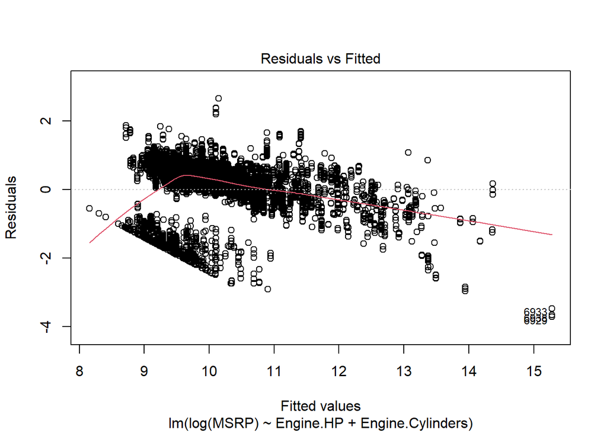

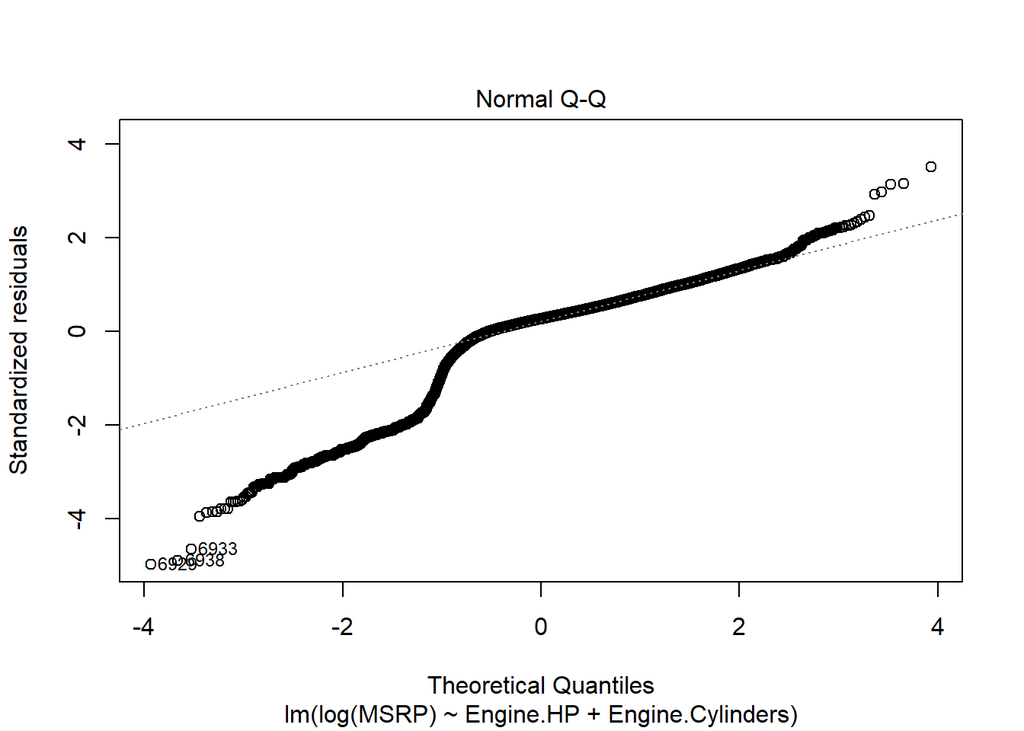

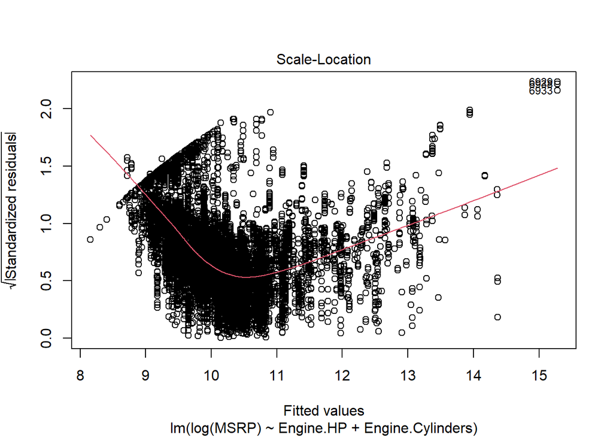

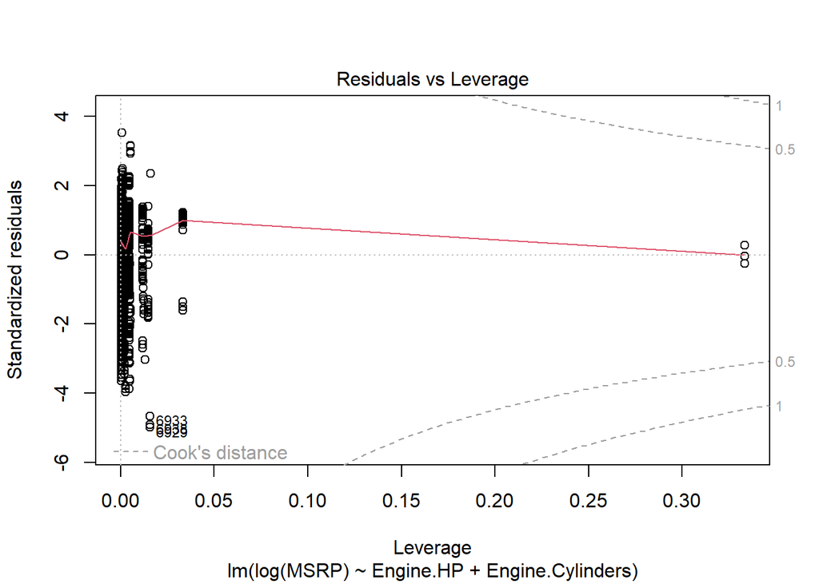

```r
first_fir <- lm(log(MSRP)~Engine.HP+Engine.Cylinders,car_data)
plot(first_fir)
```

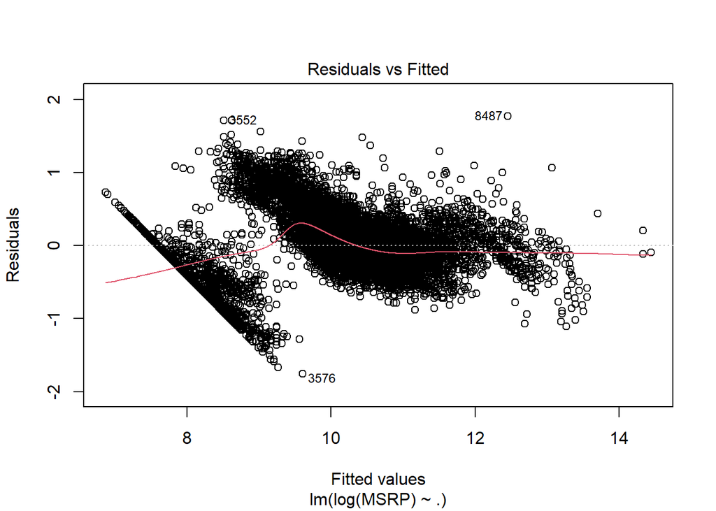

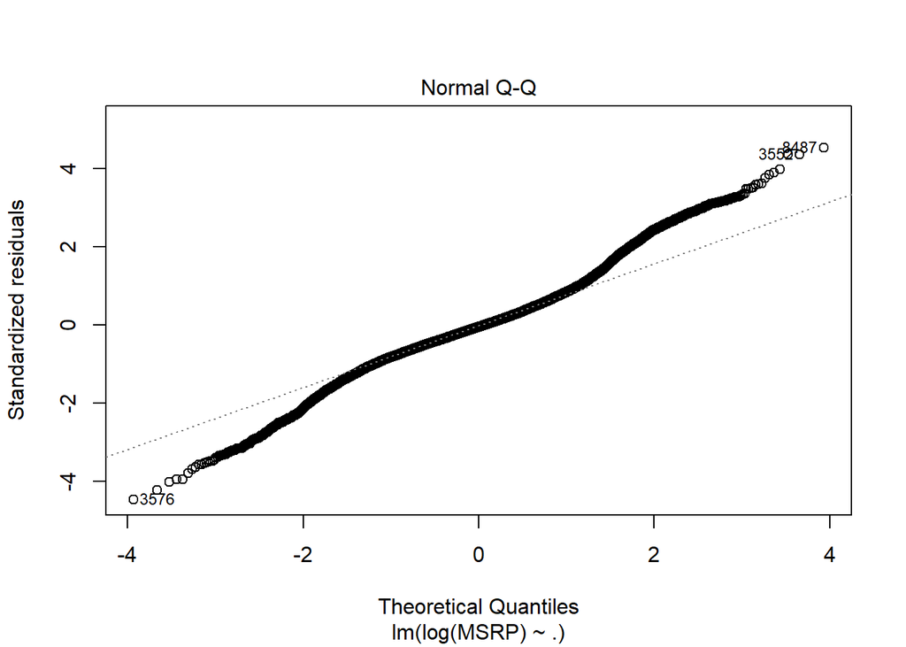

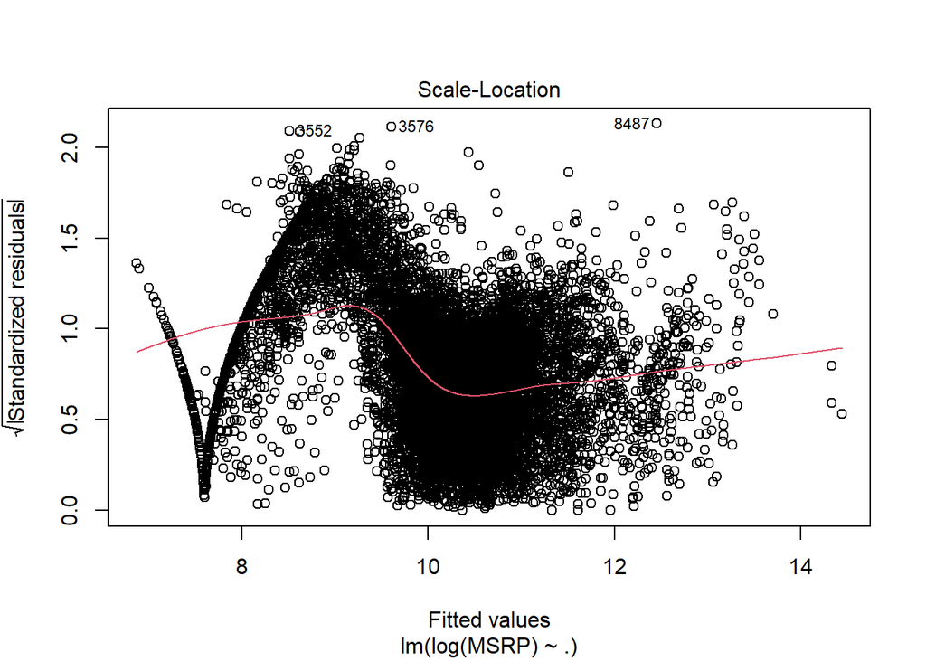

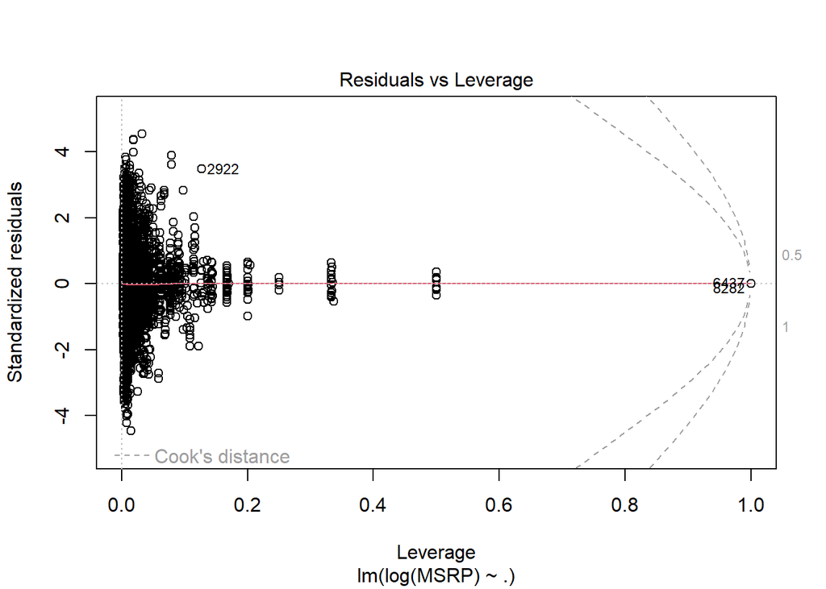

```r
model_1 <- lm(log(MSRP)~.,car_data)
plot(model_1)
```

```r
set.seed(7)

fitControl <- trainControl(method = "repeatedcv", number = 5, repeats = 1)
glmnet.fit <- train(log(MSRP)~.,
                    data = car_data,
                    method = "glmnet",
                    trControl = fitControl)

glmnet.fit
```

```
## glmnet
##
## 11914 samples
##    14 predictor
##
## No pre-processing
## Resampling: Cross-Validated (5 fold, repeated 1 times)
## Summary of sample sizes: 9531, 9532, 9532, 9531, 9530
## Resampling results across tuning parameters:
##
##   alpha  lambda      RMSE       Rsquared   MAE
##   0.10   0.00169881  0.3993965  0.8696044  0.2938101
##   0.10   0.01698810  0.4032061  0.8672794  0.2961710
##   0.10   0.16988098  0.4456008  0.8458812  0.3283990
##   0.55   0.00169881  0.4002989  0.8690290  0.2947519
##   0.55   0.01698810  0.4156295  0.8594152  0.3092352
##   0.55   0.16988098  0.5066966  0.8118731  0.3751229
##   1.00   0.00169881  0.4012458  0.8684290  0.2957554
##   1.00   0.01698810  0.4316365  0.8486724  0.3249176
##   1.00   0.16988098  0.5474842  0.7914243  0.3997248
##
## RMSE was used to select the optimal model using the smallest value.
## The final values used for the model were alpha = 0.1 and lambda = 0.00169881.
```

```r
opt.pen<- glmnet.fit$finalModel$lambdaOpt
coef(glmnet.fit$finalModel,opt.pen)
```

```
## 165 x 1 sparse Matrix of class "dgCMatrix"
##                                                                                  s1
## (Intercept)                                                           -2.008151e+02
## MakeAlfa Romeo                                                         1.883532e-01
## MakeAston Martin                                                       3.607665e-01
## MakeAudi                                                              -7.421813e-02
## MakeBentley                                                           -2.951081e-01
## MakeBMW                                                               -4.052534e-02
## MakeBugatti                                                            1.490000e+00
## MakeBuick                                                             -2.647496e-02
## MakeCadillac                                                           1.833293e-01
## MakeChevrolet                                                          2.627962e-02
## MakeChrysler                                                           2.553782e-03
## MakeDodge                                                             -5.518954e-02
## MakeFerrari                                                            1.143693e+00
## MakeFIAT                                                              -3.282071e-01
## MakeFord                                                               .
## MakeGenesis                                                           -2.168204e-01
## MakeGMC                                                                6.449359e-02
## MakeHonda                                                             -4.597830e-03
## MakeHUMMER                                                             4.203334e-01
## MakeHyundai                                                           -9.768465e-02
## MakeInfiniti                                                           1.976172e-05
## MakeKia                                                               -1.798711e-01
## MakeLamborghini                                                        6.693985e-01
## MakeLand Rover                                                         2.119159e-01
## MakeLexus                                                             -2.636006e-02
## MakeLincoln                                                            1.100350e-01
## MakeLotus                                                              6.301486e-01
## MakeMaserati                                                          -8.086451e-01
## MakeMaybach                                                           -3.367639e-01
## MakeMazda                                                              3.114370e-02
## MakeMcLaren                                                            8.292306e-01
## MakeMercedes-Benz                                                     -2.209529e-01
## MakeMitsubishi                                                        -5.270607e-02
## MakeNissan                                                            -2.199062e-01
## MakeOldsmobile                                                        -9.125976e-02
## MakePlymouth                                                          -4.862748e-01
## MakePontiac                                                            2.985038e-01
## MakePorsche                                                            1.851428e-01
```

[output cut: 112 more lines]

```
## Vehicle.StyleCargo Minivan                                            -1.363885e-01
## Vehicle.StyleCargo Van                                                -6.401118e-01
## Vehicle.StyleConvertible                                               2.935478e-01
## Vehicle.StyleConvertible SUV                                           1.969221e-01
## Vehicle.StyleCoupe                                                     1.358476e-01
## Vehicle.StyleCrew Cab Pickup                                          -1.277508e-01
## Vehicle.StyleExtended Cab Pickup                                      -2.275118e-01
## Vehicle.StylePassenger Minivan                                         1.790301e-04
## Vehicle.StylePassenger Van                                            -5.307957e-01
## Vehicle.StyleRegular Cab Pickup                                       -1.666700e-01
## Vehicle.StyleSedan                                                    -4.389581e-02
## Vehicle.StyleWagon                                                     6.041566e-02
## highway.MPG                                                           -3.161394e-02
## city.mpg                                                              -4.716019e-03
## Popularity                                                            -4.511843e-06
```